# Streaked Horned Lark Preliminary Analysis

John D Lloyd

2022-11-03

## Distance sampling

As expected, most of the detections of singing, male Streaked Horned Larks occured in the middle two distance bands (26-100 m and 101-200 m, respectively).

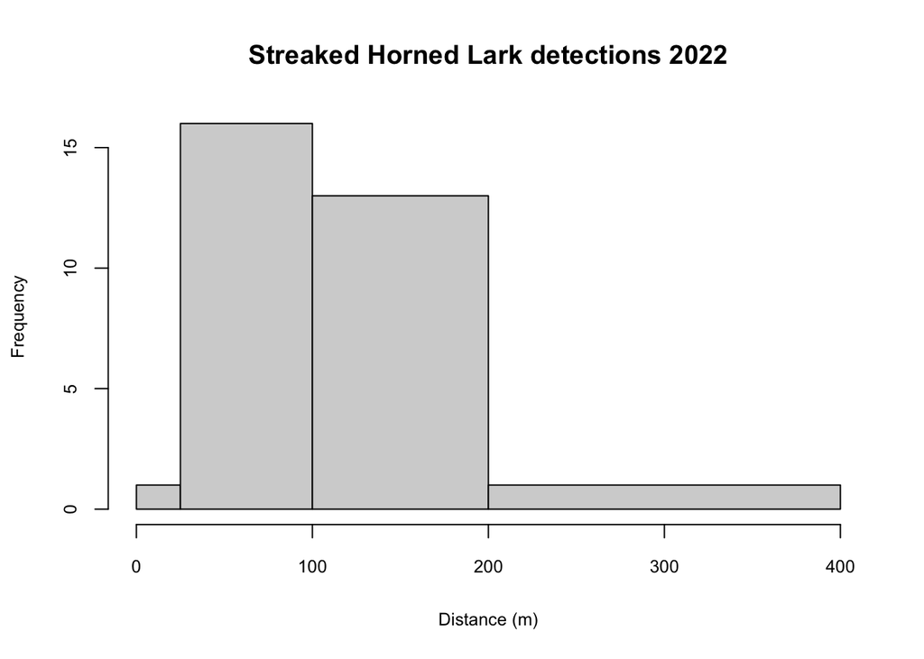

Having imported the data and created the necessary data frames, we can fit a series of distance-sampling models. In this example, I’ve constructed all of the single-factor covariate models using both a half-normal and hazard-rate detection function.

The best-supported model, based on the AICc scores, is the half-normal model that includes day-of-year as a covariate.

```
##
## Model selection based on AICc:
##
##         K   AICc Delta_AICc AICcWt Cum.Wt      LL
## hnDay   3 247.49       0.00   0.59   0.59 -120.69
## haDay   4 249.78       2.29   0.19   0.78 -120.79
## hnNoise 3 252.50       5.01   0.05   0.82 -123.19
## hnTemp  3 252.68       5.19   0.04   0.87 -123.28
## hnNull  2 252.73       5.24   0.04   0.91 -124.34
## haNoise 4 253.83       6.34   0.02   0.93 -122.82
## haTemp  4 254.00       6.51   0.02   0.96 -122.91
## hnMAS   3 254.37       6.88   0.02   0.98 -124.13
## haNull  3 254.53       7.04   0.02   0.99 -124.21
## haMAS   4 256.57       9.08   0.01   1.00 -124.19
```

Using a parametric bootstrap to examine goodness-of-fit, it seems that this model fits the data adequately. Two of the three tests (Chi-square and Freeman-Tukey) indicated no deviation from expections (both bootstrap P-values > 0.385). However, the test based on the sum of squared errors (SSE) indicates that model fit may not be good. This may be a result of the rather small sample size, so I proceeded even though not all tests agreed that goodness-of-fit was adequate. In the output below, t0 are the observed values of the statistics, and tB are the bootstrapped estimates of the same statistics. In a well-fitting model, the observed and bootstrapped statistics should be similar.

```
## t0 = 42.81292 750.2534 48.03111
```

```
##
## Call: parboot(object = hnDay, statistic = fitstats, nsim = 25, report = 50)
##
## Parametric Bootstrap Statistics:
##                 t0 mean(t0 - t_B) StdDev(t0 - t_B) Pr(t_B > t0)
## SSE           42.8         10.035             4.17          0.0
## Chisq        750.3        -72.638           290.90          0.5
## freemanTukey  48.0         -0.514             5.75          0.5
##
## t_B quantiles:
##               0% 2.5% 25% 50% 75% 97.5% 100%
## SSE           23   25  31  33  35    40   41
## Chisq        594  598 660 755 821  1562 1876
## freemanTukey  35   37  47  49  52    58   58
##
## t0 = Original statistic computed from data
## t_B = Vector of bootstrap samples
```

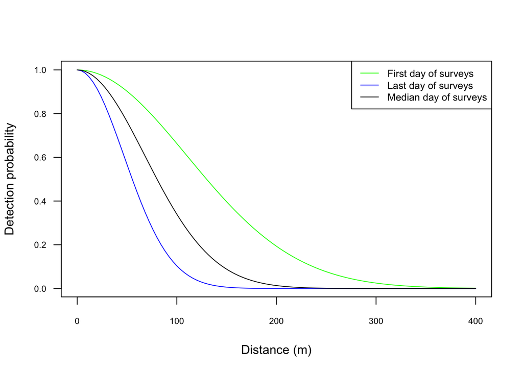

The probability (p) of detecting a lark is 0.06 on the median day of surveys, with an effective radius (ER) of 96.2 m.

```
##           p          er
##  0.05791769 96.26437560
```

The 95% confidence limits for p and for ER (t_B quantiles 2.5%, 97.5%):

```
## t0 = 0.05791769 96.26438
```

[output not shown]

The estimated number of larks per square km = 4.33.

```
## Backtransformed linear combination(s) of Density estimate(s)
##
##  Estimate   SE LinComb (Intercept)
##      4.33 1.22    1.47           1
##
## Transformation: exp
```

The boostrapped 95% confidence interval around the density estimate (t_B quantiles 2.5%, 97.5%):

```
## t0 = 4.327875
```

```
##
## Call: parboot(object = hnDay, statistic = getD, nsim = 25, report = 50)
##
## Parametric Bootstrap Statistics:
##     t0 mean(t0 - t_B) StdDev(t0 - t_B) Pr(t_B > t0)
## 1 4.33         -0.483             1.26          0.5
##
## t_B quantiles:
##      0% 2.5% 25% 50% 75% 97.5% 100%
## t*1 2.8  3.1 3.9 4.6 5.5   7.1  7.5
##
## t0 = Original statistic computed from data
## t_B = Vector of bootstrap samples
```

The estimated density seems significantly higher than current estimates of Streaked Horned Lark population size would predict, probably a result of the very low estimate of detectability.

Using combined distance and removal models, we can estimate detectability:

```r
summary(drDay)
```

```
##
## Call:
## gdistremoval(lambdaformula = ~1, phiformula = ~1, removalformula = ~1,
##     distanceformula = ~dayOfYear, data = umfDR, keyfun = "halfnorm",
##     output = "density", unitsOut = "kmsq", mixture = "ZIP")
##
## Abundance (log-scale):
##  Estimate    SE    z  P(>|z|)
##      3.63 0.519 6.99 2.67e-12
##
## Dispersion (log-scale):
##  Estimate    SE    z  P(>|z|)
##      1.57 0.335 4.68 2.85e-06
##
## Distance (log-scale):
##             Estimate     SE     z P(>|z|)
## (Intercept)   8.4518 2.9642  2.85 0.00435
## dayOfYear    -0.0245 0.0176 -1.39 0.16556
##
## Removal (logit-scale):
##  Estimate    SE     z P(>|z|)
##     -1.26 0.746 -1.69  0.0909
##
## AIC: 296.4536
## Number of sites: 214
## optim convergence code: 0
## optim iterations: 67
## Bootstrap iterations: 0
```

```r
getPdistrem <- function(x) {
  sig <- backTransform(linearComb(drDay,c(1,171), type = "dist"))
  ea <- 2*pi * integrate(grhn, 0, 400, sigma=sig@estimate)$value # effective area
  er <- sqrt(ea / pi) # effective radius
  p <- ea / (pi*400^2) #detection probability
  return(p)
}
getPdistrem(drDay)
```

```
## [1] 0.06372673
```

and availability:

```
## Backtransformed linear combination(s) of Removal estimate(s)
##
##  Estimate    SE LinComb (Intercept)
##     0.221 0.128   -1.26           1
##
## Transformation: logistic
```

and their product:

```r
getPD <- function(x) {
  d <- backTransform(drDay, type = "rem")
  sig <- backTransform(linearComb(drDay,c(1,171), type = "dist"))
  ea <- 2*pi * integrate(grhn, 0, 400, sigma=sig@estimate)$value # effective area
  er <- sqrt(ea / pi) # effective radius
  p <- ea / (pi*400^2) #detection probability
  Pd <- p*(d@estimate)
  return(Pd)
}
getPD(drDay)
```

```
## [1] 0.01407129
```